# Duomenų analizė

# 3 Hierarchinė analizė

## 3.1 Duomenų paruošimas hierarchinei analizei

```r
duomenys_paruost <- duomenys_[, -1] %>% select_if(is.numeric)
```

## 3.2 Duomenų standartizavimas

```r
duomenys_standart <- scale(duomenys_paruost)
```

Standartizavimas buvo atliktas, kadangi yra reikšmių sritys, kurios skiriasi keletų eilių.

## 3.3 Hierarchinė klasterizacija

```r
eclust_rez_duomenu <-
  eclust(
    duomenys_standart, stand = TRUE, nboot = 500, k.max = 10,
    FUNcluster = "hclust", hc_metric = "euclidean", hc_method = "ward.D2"
  )
```

## 3.4 Klusteriu optimalaus kiekio nustatymas grafiku

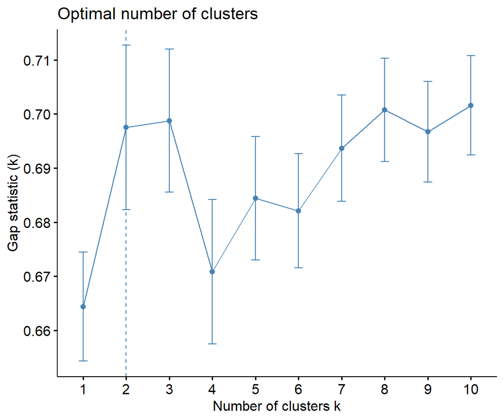

```r
fviz_gap_stat(eclust_rez_duomenu$gap_stat)
```

## 3.5 Optimalus klusterių kiekio nustatymas

```r
eclust_rez_duomenu$nbclust
```

```
## [1] 2
```

Nustatyta, kad užtenka 2 klusterių.

## 3.6 Silueto grafikas

```
##   cluster size ave.sil.width
## 1       1  217          0.11
## 2       2  352          0.47
```

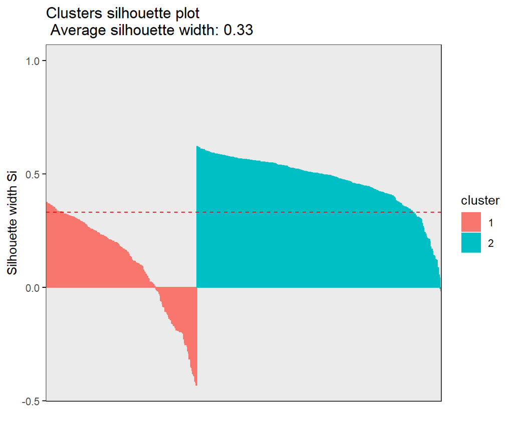

```r
fviz_silhouette(eclust_rez_duomenu)
```

## 3.7 Dendograma

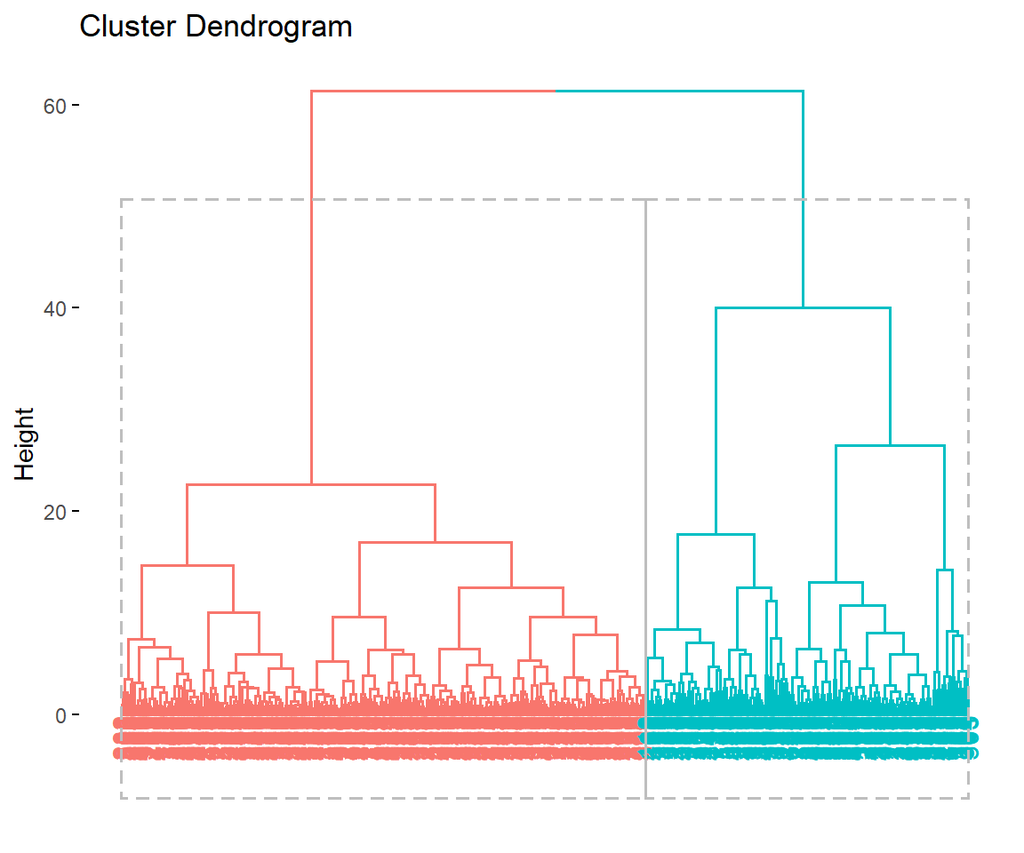

```r
fviz_dend(eclust_rez_duomenu, rect = TRUE)
```

Iš dendogramos galima matyti du aiškius klusterius.

## 3.8 PCA pagrįstas sklaidos grafikas

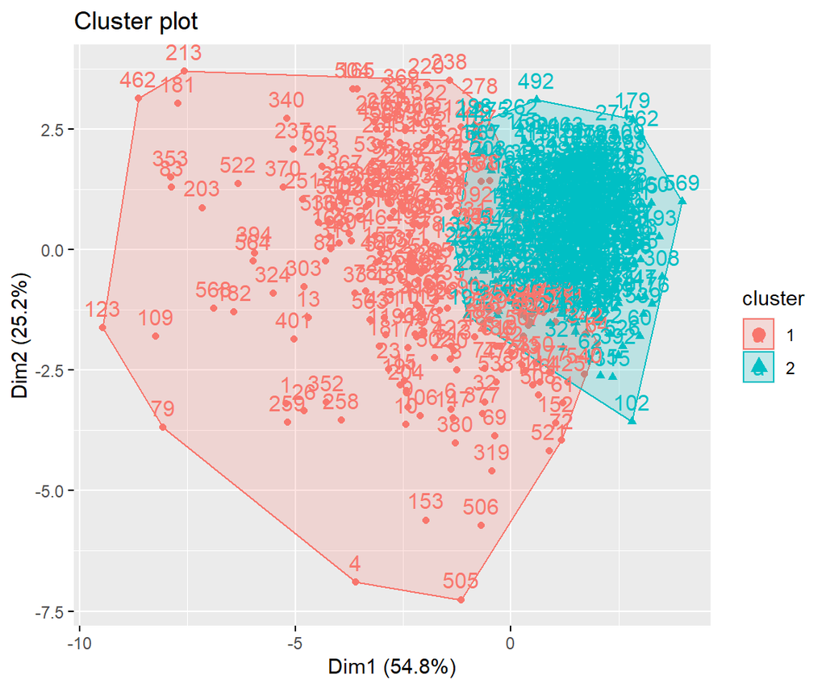

```r
fviz_cluster(eclust_rez_duomenu)
```

PCA pagrįstas sklaidos grafikas rodo, kad klasteriai šiek tiek persidengia.

## 3.9 Klusterių taškams “vardų priskirimas”

```r
eclust_rez_duomenu$cluster
```

```
##   [1] 1 1 1 1 1 1 1 1 1 1 2 1 1 2 1 1 2 1 1 2 1 2 1 1 1 1 1 1 1 1 1 1 1 1 1 1 2
##  [38] 2 2 2 2 1 1 1 2 1 2 1 2 2 2 2 2 1 2 2 1 1 2 2 1 2 1 1 2 1 2 2 1 2 1 1 1 2
##  [75] 2 1 1 1 1 2 2 1 1 1 2 1 2 1 2 1 2 1 2 2 1 1 2 2 2 2 2 2 2 2 2 1 1 2 1 2 2
## [112] 2 1 1 2 2 2 1 1 2 2 1 1 2 2 2 2 1 1 1 2 1 2 2 1 2 2 2 1 1 2 1 2 2 2 1 1 2
## [149] 2 2 1 1 1 2 2 2 1 2 2 2 1 1 1 2 1 2 2 1 1 2 2 2 1 2 2 2 1 1 2 2 1 1 2 2 2
## [186] 2 1 2 2 2 1 2 2 2 1 2 2 2 1 2 2 1 1 1 2 2 2 2 2 2 1 2 1 1 2 1 2 2 1 1 2 2
## [223] 2 2 2 2 2 2 2 1 1 2 2 1 2 2 1 1 2 1 2 2 1 2 1 2 2 2 2 2 1 2 1 1 1 2 1 1 1
## [260] 1 1 2 1 2 1 1 2 2 2 2 2 2 1 2 2 1 2 1 2 2 1 2 1 1 2 2 2 2 1 2 2 2 2 2 2 2
## [297] 2 2 2 2 1 2 1 2 2 2 2 2 2 2 2 2 2 2 2 2 2 1 1 2 2 1 2 1 2 2 2 2 1 1 1 2 2
## [334] 2 2 1 2 1 2 1 2 1 2 1 1 2 2 2 2 1 2 1 1 1 2 2 1 2 2 2 2 2 2 2 2 1 1 2 1 1
## [371] 1 2 1 1 2 2 1 2 2 1 1 2 2 2 2 2 2 2 1 1 2 2 1 1 2 2 2 2 2 2 1 2 2 2 2 2 2
## [408] 2 1 2 2 2 2 2 2 2 2 1 2 2 2 1 1 2 1 2 2 2 2 2 1 2 1 1 2 2 2 2 2 2 2 2 2 2
## [445] 1 2 1 2 2 1 2 1 2 2 2 2 2 2 2 2 1 1 2 2 2 2 2 2 1 1 2 2 2 2 2 2 2 2 2 1 2
## [482] 2 2 2 2 1 2 1 1 2 2 2 1 2 2 2 2 2 1 1 2 1 1 1 1 1 1 1 2 1 2 2 1 2 2 2 1 1
## [519] 1 1 1 1 2 2 2 2 2 2 1 2 2 2 2 1 2 1 2 1 2 1 2 2 2 2 2 2 2 2 2 2 2 2 2 2 2
## [556] 2 2 2 2 2 2 2 1 1 1 1 2 1 2
```

## 3.10 Klasteriuose bendras taškų pasiskirstymas

```r
with(eclust_rez_duomenu, table(cluster))
```

```
## cluster
##   1   2
## 217 352
```

## 3.11 Gautas hierarchinės klasterizacijos rezultatas

```r
eclust_rez_duomenu
```

```
##
## Call:
## stats::hclust(d = x, method = hc_method)
##
## Cluster method   : ward.D2
## Distance         : euclidean
## Number of objects: 569
```

## 3.12 Rezulatų palyginimas su tikrais duomenimis

```r
hierarch_klasterizacija <- eclust_rez_duomenu$cluster
tikri_duomenys <- duomenys_$diagnoze
```

```r
sukryzminti_duomenys <- table(hierarch_klasterizacija, tikri_duomenys)
sukryzminti_duomenys
```

```
##                        tikri_duomenys
## hierarch_klasterizacija   B   M
##                       1  47 170
##                       2 310  42
```

## 3.13 Atvaizdavimas sukryžmintų (palygintų) duomenų grafiškai

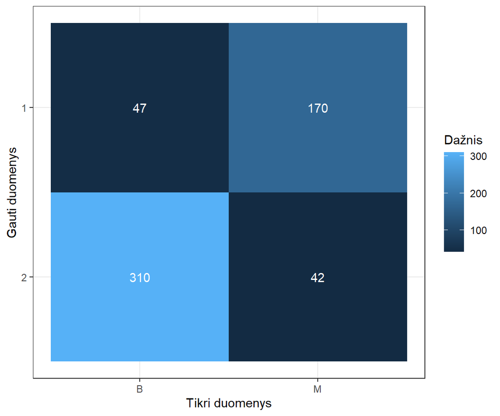

```r
as.data.frame(sukryzminti_duomenys) %>%
  ggplot(aes(x = tikri_duomenys, y = hierarch_klasterizacija, fill = Freq, label = Freq)) +
  geom_tile() +
  geom_text(color = "white") +
  scale_y_discrete(limits = rev) +
  labs(x = "Tikri duomenys",
       y = "Gauti duomenys",
       fill = "Dažnis")
```

Iš grafiko galime matyti, kad hierarchinis klasterizavimas atskyrė klasterius nevisiškai teisingai lyginant su nustatytomis tikromis diagnozėmis.

# 4 Daugiamačių skalių (klasikinis PCoA) metodas

## 4.1 Atstumų nustatymas panaudojant standartizuotus duomenis

```r
duomenys_atstum <- duomenys_standart %>%  dist(method = "euclidean")
```

Standartizuoti duomenis paimti iš prieš tai atliktos hierarchinės analizės.

## 4.2 Grafiškai atvaizduoti atstumai

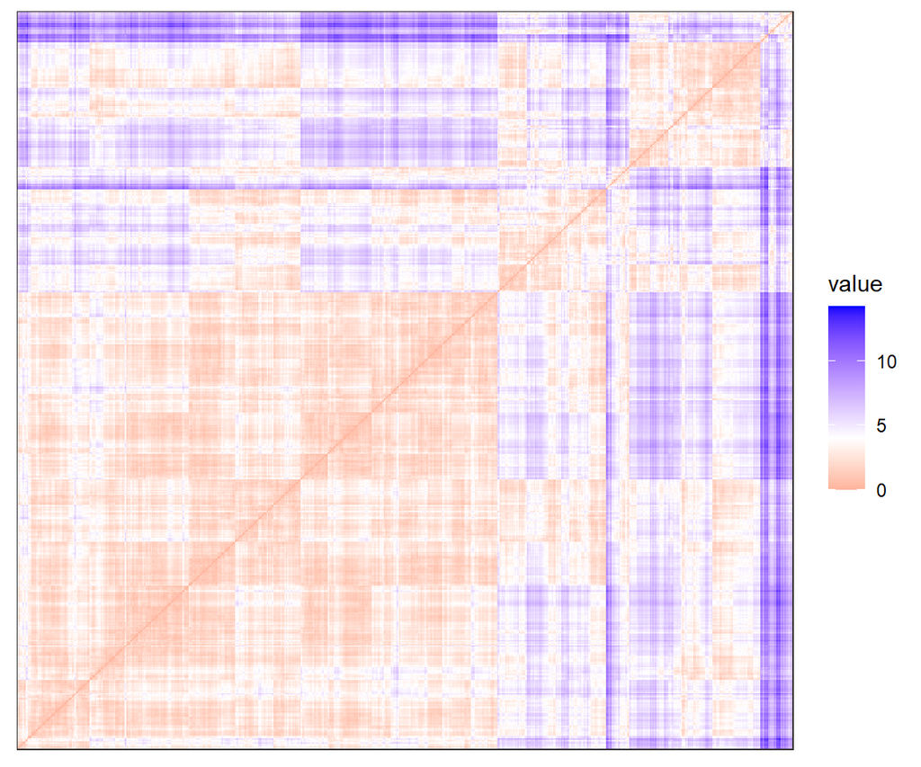

```r
factoextra::fviz_dist(duomenys_atstum, show_labels = FALSE)
```

Matomas vienas aiškus ir didelis klusteris ir du maži klusteriai iš viso trys klusteriai.

## 4.3 Principinių koordinačių analizė

```r
pcoa_duomenys <- cmdscale(duomenys_atstum, k = 3, eig = TRUE)
```

## 4.4 Grafikas savitajai (anlg. eigenvalue) reikšmei

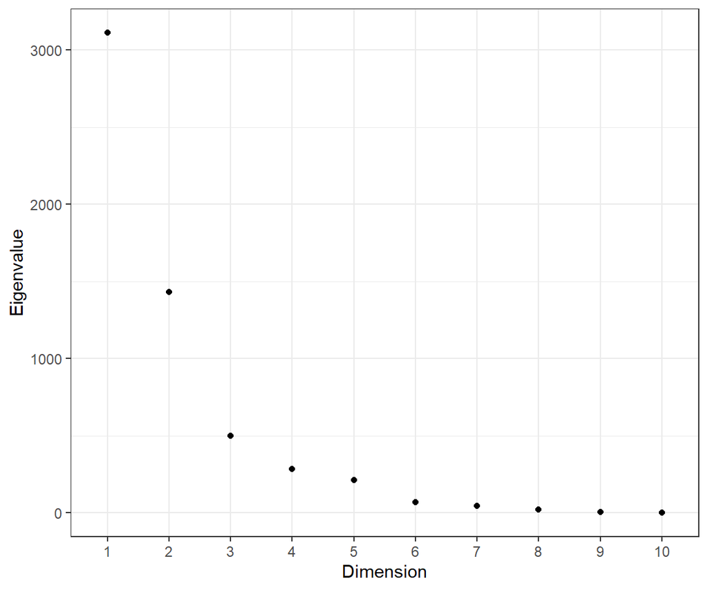

```r
ind <- 1:10
qplot(factor(ind), pcoa_duomenys$eig[ind], xlab = "Dimension", ylab = "Eigenvalue")
```

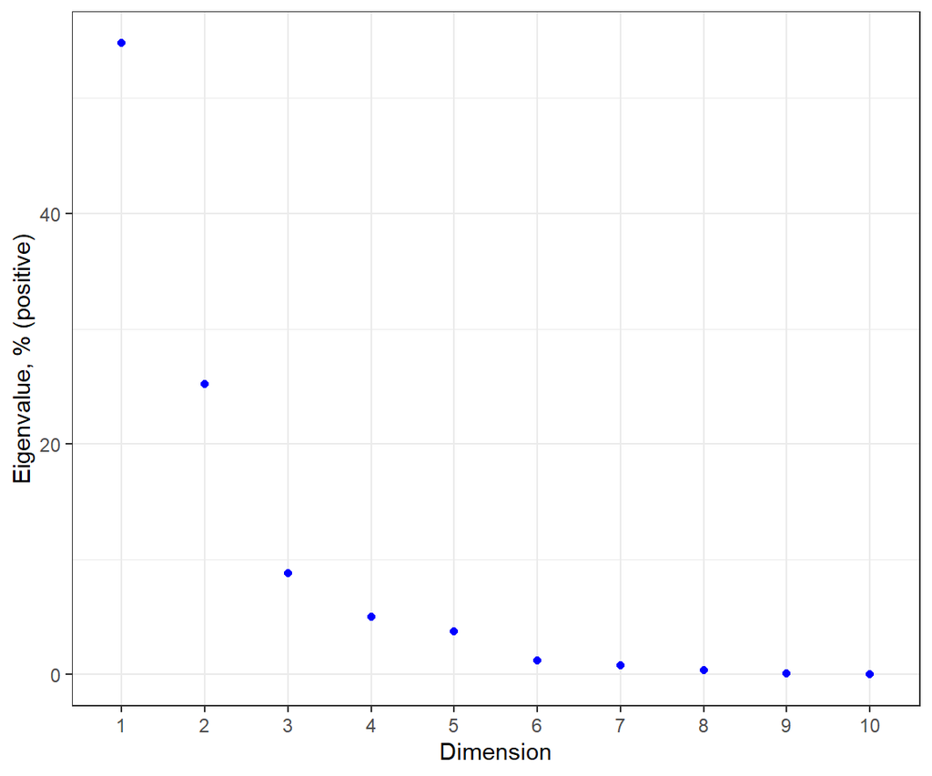

```r
rel_eig_2 <- pcoa_duomenys$eig[ind]/sum(pcoa_duomenys$eig[pcoa_duomenys$eig > 0])
qplot(
  x = factor(ind), y = rel_eig_2[ind] * 100, color = I("blue"),
  xlab = "Dimension", ylab = "Eigenvalue, % (positive)"
)
```

## 4.6 Gerumo kriterijus

```r
pcoa_duomenys$GOF
```

```
## [1] 0.8877917 0.8877917
```

Iš gerumo kriterijaus 0.8877917, 0.8877917 galime matyti, kad objektų išdėstymas mažo dimensiškumo erdvėje pakankamai gerai atitinka objektų išdėstymą didelio dimensiškumo erdvėje.

## 4.7 Koordinatės daugiamačių skalių analizės erdvėje

```r
pcoa_coord_duomenys <- as.data.frame(pcoa_duomenys$points)
pcoa_coord_duomenys %>% head()
```

```
##          V1         V2         V3
## 1 -5.219562  3.2016111  2.1694307
## 2 -1.726575 -2.5386054  1.0187821
## 3 -3.966267 -0.5495913  0.3232843
## 4 -3.593551  6.8989994 -0.7921346
## 5 -3.148321 -1.3568784  1.8605969
## 6 -1.380105  3.3114977  0.6973879
```

## 4.8 Daugiamačių skalių analizės grafikas atvaizduotas ggplot2

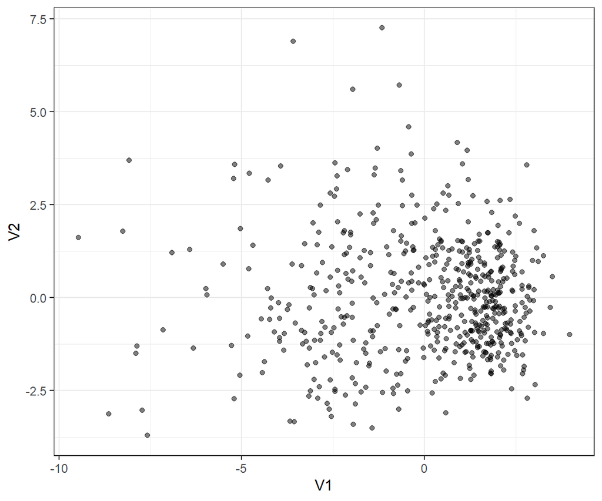

```r
ggplot(pcoa_coord_duomenys, aes(V1, V2)) +
  geom_point(alpha = 0.5)
```

## 4.9 Daugiamačių skalių analizės grafikas atvaizduotas spalvomis pagal diagnoze

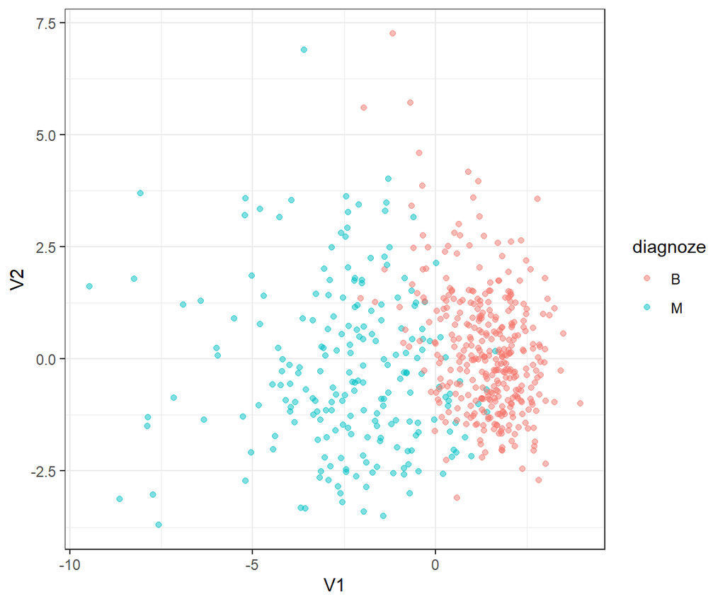

```r
pcoa_coord_duomenys %>%
  bind_cols(duomenys_) %>%
  ggplot(aes(V1, V2, color = diagnoze)) +
  geom_point(alpha = 0.5)
```

Iš grafiko galime matyti pasiskirstymą pagal spalvas dviejų klusterių.

R markdown panaudota sintaksė:

```
Italics
Bold
"Bullet list"
Kodo atsakymo citavimas tekste
Nuorodos į paveikslus
Lygties pavaizdavimas
***
```